# Analysis of Civil War Outbreak

Alec Albright

March 4, 2019

# Introduction

## Background

With the rise of civil wars within countries since the end of World War II, researchers and theorists have become more and more concerned with understanding what may contribute to the start of a civil war, occasionally in attempts to predict the likelihood of such an event happening. Thus, throughout this analysis, we will be analyzing a few models to see what can most reliably and accurately serve as a predictive model of whether civil war will break out in any given country.

## Data

The data set that we are using to conduct our analysis is a data frame with 688 rows and 11 columns, each column representing a different variable. In this case, each row represents the data for a specific country within a 5 year period and holding several variables constant: the number of months since the country’s last war, annual GDP growth rate, secondary school ennrollment, dependency on commodity exports, geographic concentration of population, the natural logarithm of population, social division along ethnic/religious lines, and ethnic dominance.

To begin, we will look at boxplots of these variables against the levels of our response, “start”, to see if there are any noticeable relationships before we begin fitting models. Note: Because dominance is a factor, we will be making a histogram instead.

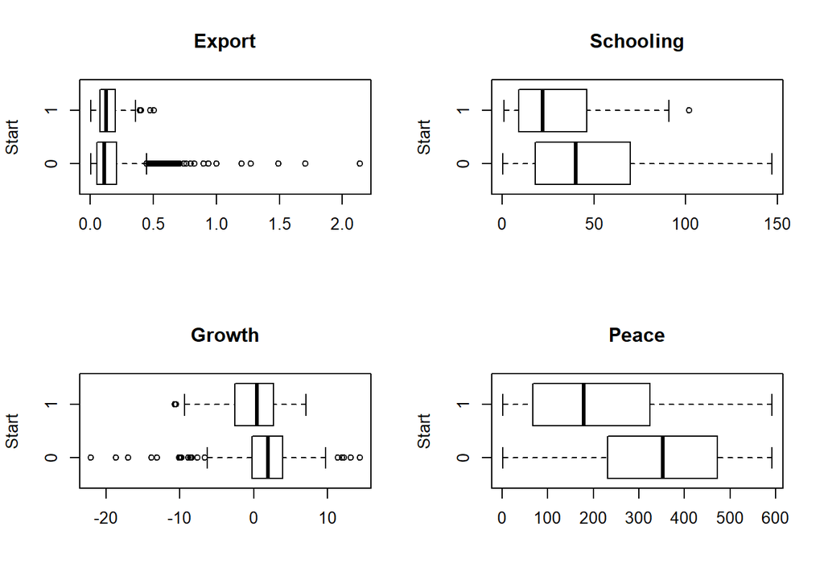

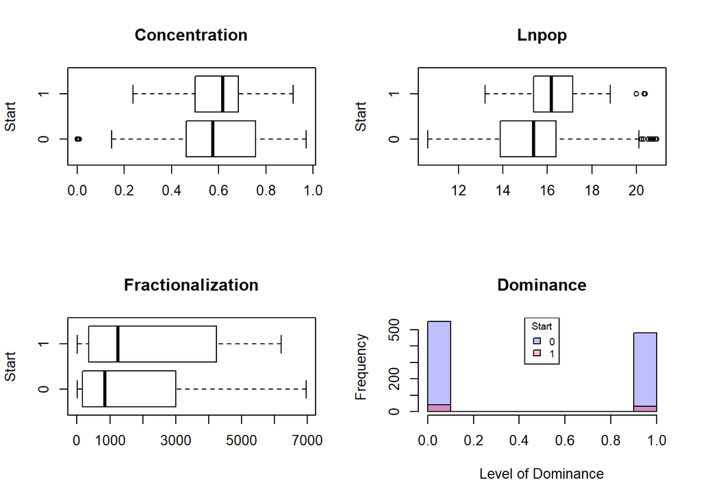

After the exploratory data analysis of these variables, we can see that for nearly every explanatory variable (except perhaps dominance, which is a factor), there is a noticeable difference in variance or general shape/distribution of the data when conditioned on “start”. For this reason, when we look to fit our model predicting start from these variables, we will initially include all of these variables, as we cannot conclude currently that any of the variables have no significant relationship with “Start”.

As we move forward, we will be omitting the rows of the initial data set that include NAs, as the incomplete rows would not be used in any of our model-estimating functions moving forward.

## The Baseline Theory

Because 0 is the most frequent class in the start variable of the civil war dataset, we begin model assumptions starting from the baseline classifier that always predicts start = 0 (no civil war will start):

$$\hat{\mu}(x) = 0 \quad \text{for all x}$$

## The Suggested Theories

One theory discussing what circumstances may make a country vulnerable to a civil war outbreak posits that civil wars are easier to start in countries whose economies are heavily dependent on commodity exports. Therefore, the model assumed by this theory is:

$$\text{start}_i = \beta_{0}E_i + \epsilon_i$$

Where $E_i$ is the country’s dependency on commodity exports.

Another theory on this topic claims that strong ethnic divisions and domination of one ethnic group are important factors to whether a civil war will begin. Therefore, the model assumed by this theory is:

$$\text{start}_i = \beta_0F_i + \beta_1D_i + \epsilon_i$$

Where $F_i$ is the country’s fractionalization index and $D_i$ is the country’s dominance level (either 0 or 1).

# Models

## a)

We will now estimate these models to the original data set. We are also going to estimate another model that includes all of the variables in the data set since there was no reason to believe that any of the original variables have no relationship with the “Start” response variable. Because “Start” is a binary outcome, we will be fitting logistic regression models with the respective variables from each theory as well as the full model as recently discussed. This will allow us to more accurately model the conditional probabilities of “Start” = 0 and “Start” = 1 given the values of the other variables of interest.

Given this full model, we will do some bootstaping to see if all of the variables included in the full model are important in predicting the outbreak of civil war. The 95% confidence intervals for the coefficients on the variables included in the full logistic regression model are:

```
##                            lower         upper
## (Intercept)        -1.861426e+01 -17.507591292
## exports             6.031762e+00   6.760213217
## schooling          -5.361232e-02  -0.050146680
## growth             -2.737962e-01  -0.246385713
## peace              -8.113259e-03  -0.007443691
## concentration      -3.671170e+00  -3.222094124
## lnpop               1.082790e+00   1.147347077
## fractionalization  -2.747699e-04  -0.000227428
## factor(dominance)1  1.081332e+00   1.268805879
```

Because none of these 95% confidence intervals include 0, we cannot include that any of these variables have no significant relationship with the outbreak of civil wars, so we will continue moving forward with the the full logistic regression model as well as the logistic regression models based on the suggested theories.

## b)

The estimated coefficients for the logistic regression based on the first theory (predicting start from exports) and their standard errors are:

```
##               Estimate Std. Error    z value     Pr(>|z|)
## (Intercept) -2.7093739  0.2299152 -11.784229 4.707063e-32
## exports      0.4531007  1.0347670   0.437877 6.614754e-01
```

The estimated coefficients for the logistic regression based on the second theory (predicting start from freactionalization and dominance) and their standard errors are:

```
##                         Estimate   Std. Error     z value     Pr(>|z|)
## (Intercept)        -2.852796e+00 2.627403e-01 -10.8578556 1.829959e-27
## fractionalization   9.115554e-05 7.253934e-05   1.2566359 2.088855e-01
## factor(dominance)1  8.694795e-02 3.073426e-01   0.2829024 7.772517e-01
```

The estimated coefficients and the standard errors for the logistic regression predicting start from all variables in the data set are:

```
##                         Estimate   Std. Error   z value     Pr(>|z|)
## (Intercept)        -9.1752676450 2.260160e+00 -4.059565 4.916412e-05
## exports             3.2800933134 1.223303e+00  2.681341 7.332770e-03
## schooling          -0.0262049915 9.024171e-03 -2.903867 3.685849e-03
## growth             -0.1360349605 4.271830e-02 -3.184466 1.450214e-03
## peace              -0.0040688688 1.098627e-03 -3.703593 2.125673e-04
## concentration      -1.7643918630 9.256921e-01 -1.906025 5.664702e-02
## lnpop               0.5706386893 1.360989e-01  4.192825 2.755025e-05
## fractionalization  -0.0001287699 8.353727e-05 -1.541466 1.232034e-01
## factor(dominance)1  0.6020783978 3.513548e-01  1.713591 8.660387e-02
```

Now, in order to further assess the measures of uncertainty for these models and evaluate which model is most reliable, we will look at their misclassification rates and their in-sample mean squared errors.

```
##                Misclassification Rate
## Theory 1                   0.06686047
## Theory 2                   0.06686047
## Full GLM Model             0.06686047
```

These misclassification rates appear to all be fairly small (approximately 0.0669), but they are all equal. This may signify that the theories as stated are nearly equally valid, but because we would like to find the best model possible for this scenario, we will now look at another measurement of uncertainty for these models: mean squared error. The MSEs of the three models are:

```
##                  MSE
## Theory 1   0.4906121
## Theory 2   0.4885773
## Full Model 0.3871492
```

With an MSE of approximately 0.4906, the logistic regression model based on the theory of dependence on commodity exports predicting the outbreak of civil war appears to have the largest amount of uncertainty of these three options. With an MSE of approximately 0.4886, the logistic regression model based on the theory of fractionalization and ethnic dominance predicting the outbreak of a civil war appears to have a slightly smaller amount of uncertainty than the first theory. With an MSE of approximately 0.3871, the full model predicting start from all other variables in the data set appears to have the smallest MSE of these options.

## c)

To begin checking the goodness of fit of our model, we will look at the plot of the residuals from the logistic regression model that we have fit to the data.

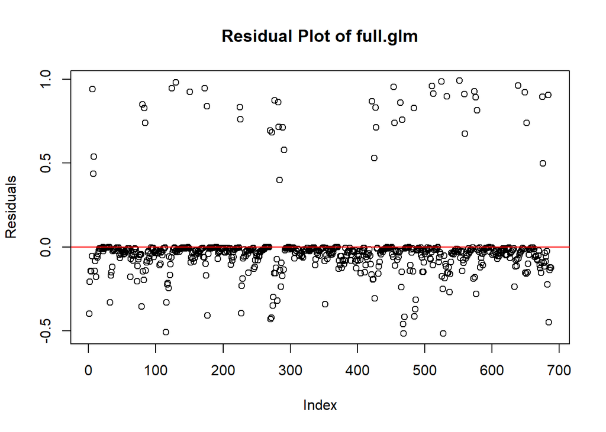

Next, we will compare the full logistic regression model to a generalized additive model for the data to see how much better an additive model may fit this data and conclude if a logistic regression model is a sufficient fit for this situation.

The initial difference in deviance between the logistic regression model and the additive model is approximately -1.72e-11, which is very small, but does suggest that the logistic regression model gives the data higher likelihood.

We now want to simulate from our fitted model, refitting both the logistic regression and additive model, to see whether this difference is significant or to be expected. This procedure will be testing whether the difference that we have observed between deviance in the full logistic regression model and the generalized additive model is statistically significant given the null hypothesis that there is no true difference in deviance between the logistic regression model the GAM model that we have fit in this scenario. In other words, we are testing:

$$H_0: D_\text{glm} = D_\text{gam} \\
H_A: D_\text{glm} \neq D_\text{gam}$$

where $D$ is the deviance for the specified model.

```
## [1] 0.17
```

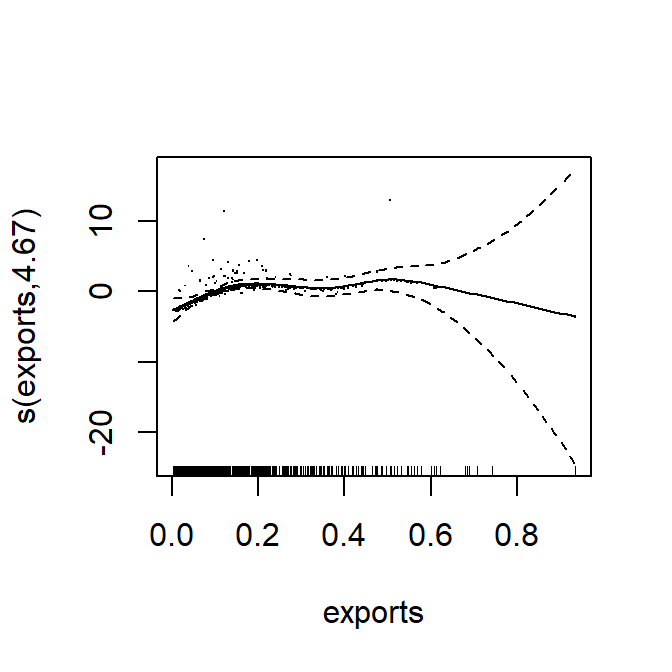

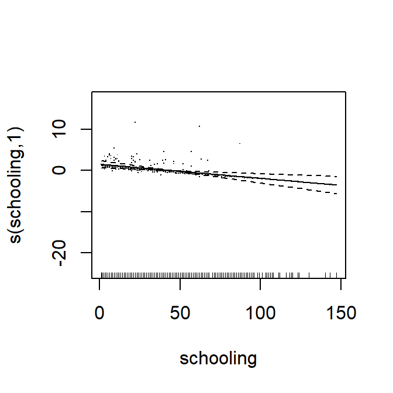

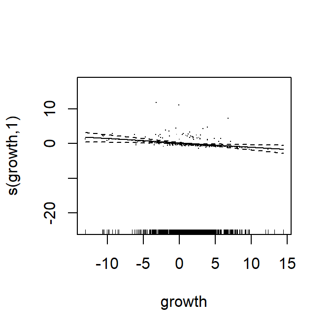

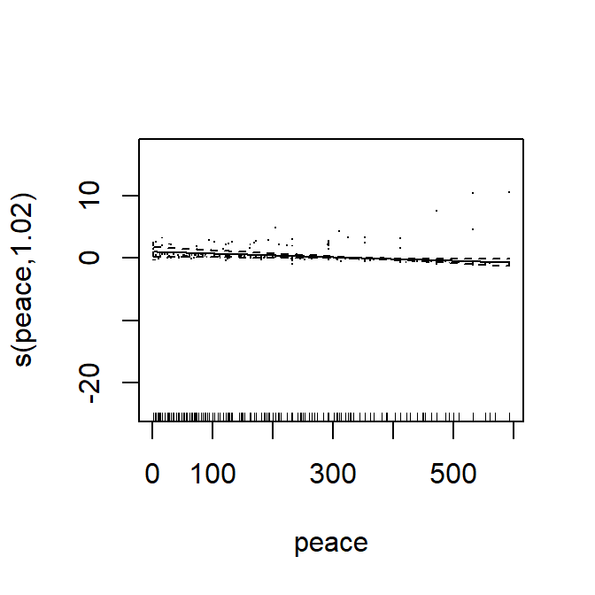

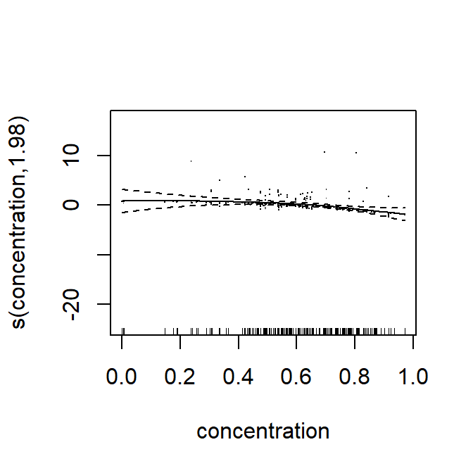

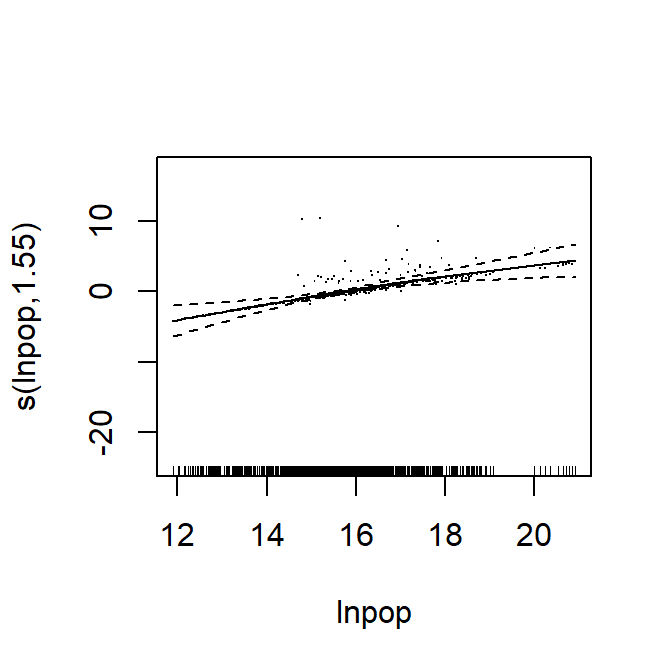

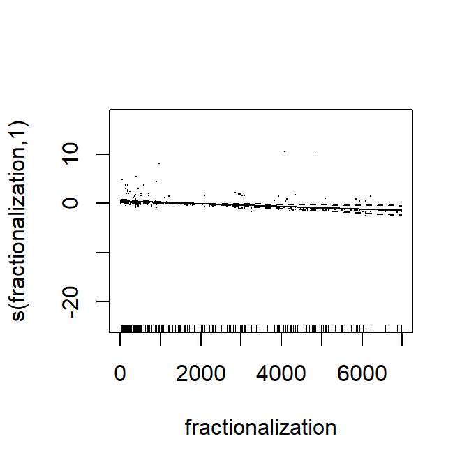

*Partial response functions estimated when we fit a GAM to the data simulated from a logistic regression*

# Results

Therefore, we arrive at the conclusion that the logistic regression model we have fit to the data, including all of the variables from the original data set, is a valid model to fit to this data.